# Homework 4: Logistic regression and judges

Jessamin Birdsall

Due: Sunday, April 19, 2015

This assignment is based on an assignment created by [German Rodriguez](http://data.princeton.edu/wws509/sets/set3.html). Topics covered include:

- reading in tabular data
- ggplot2
- logistic regression

For this assignment you will be extending the analysis in this article:

Greene and Schaffer (1992) [“Leave to Appeal and Leave to Commence Judicial Review in Canada’s Refugee-Determination System: Is the Process Fair?”](http://yorkspace.library.yorku.ca/xmlui/handle/10315/7864) International Journal of Refugee Law, 4.1: 71-83.

Here’s how the authors describe the paper: “The purpose of this study is to determine whether refugees and other persons who are applying for leave to appeal a decision of the Convention Refugee Determination Division of the Canadian Immigration and Refugee Board, a decision of the Appeal Division of the Immigration and Refugee Board, or to commence an action for judicial review have a relatively equal chance to convince the Federal Court of Appeal of the merits of their applications.”"

The data and [documentation](http://socserv.mcmaster.ca/jfox/Books/Applied-Regression-2E/datasets/Greene.pdf) were made avaialble by John Fox. I have stored a copy of the data in Greene.txt in the subfolder data.

```r
library(dplyr)
```

```r
library(ggplot2)
library(broom)
data <- read.table("data/Greene.txt")
```

Before doing anything else, just play with the data to get a sense of it.

1. The main outcome of interest is *decision* which records whether the judge granted an appeal or not. In what proprotion of cases did the judge grant an appeal.

```r
head(data)
```

```
##         judge         nation rater decision language location success
## 13      Heald        Lebanon    no       no  English  Toronto -1.0986
## 15      Heald      Sri.Lanka    no       no  English  Toronto -0.7538
## 19      Heald    El.Salvador    no      yes  English  Toronto -1.0460
## 30  MacGuigan Czechoslovakia    no      yes   French Montreal  0.4055
## 36 Desjardins        Lebanon   yes      yes   French Montreal -1.0986
## 42      Stone        Lebanon   yes      yes  English  Toronto -1.0986
```

```r
yes <- data %>%
  filter(decision == "yes") %>%
  summarise(yes <- n())

prop_yes <- yes/length(data$decision)
prop_yes
```

```
##   yes <- n()
## 1     0.2969
```

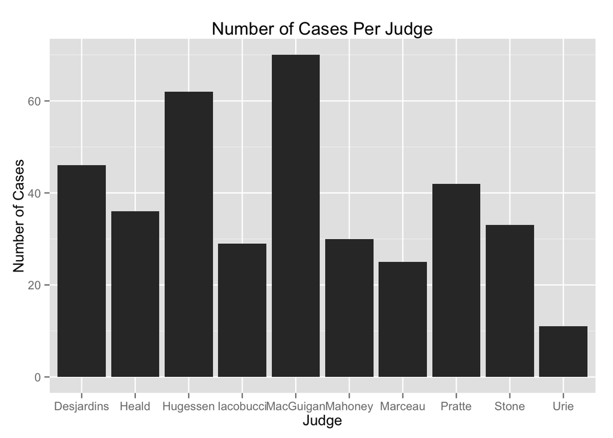

```r
cases <- data %>%
  group_by(judge) %>%
  summarise(cases = n())
p <- ggplot(data = cases, aes( x = judge, y = cases), color = "blue") + geom_bar(stat = "identity") +
  labs(x = "Judge", y = "Number of Cases") +
  ggtitle("Number of Cases Per Judge")
p
```

3. Now plot the rate at which the judges grant appeals.

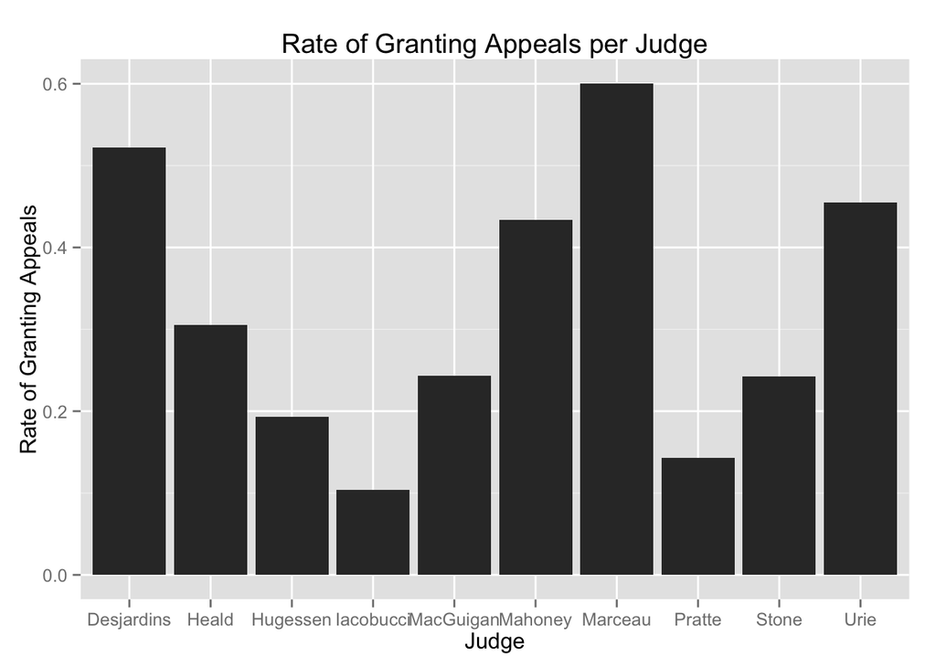

```r
rate_yes <- data %>%
  group_by(judge, decision) %>%
  filter(decision == "yes") %>%
  summarise(yes = n())

cases$yes <- rate_yes$yes

cases <- cases %>%
  mutate(rate_yes = (yes/cases))

p1 <- ggplot(data = cases, aes(x = judge, y = rate_yes)) +
  geom_bar(stat = "identity") +
  labs(x = "Judge", y = "Rate of Granting Appeals") +
  ggtitle("Rate of Granting Appeals per Judge")
p1
```

4. Now let’s try this with logistic regression because we are going to move to more complicated models. Fit a logistic regression predicting whether an appeal will be granted using judge as a categorical predictor. Use Iacobucci as the reference judge to facilitate the comparisons that follow. For more on how to control the reference level of a factor, check out this post on StackOverflow: http://stackoverflow.com/questions/3872070/how-to-force-r-to-use-a-specified-factor-level-as-reference-in-a-regression

```r
data$judge <- relevel(as.factor(data$judge), ref="Iacobucci")
fit <- glm(decision ~ judge, family = "binomial", data = data)
tidy(fit)
```

```
##               term estimate std.error statistic   p.value
## 1      (Intercept)  -2.1595    0.6097   -3.5418 0.0003974
## 2  judgeDesjardins   2.2465    0.6774    3.3163 0.0009120
## 3       judgeHeald   1.3385    0.7090    1.8879 0.0590377
## 4    judgeHugessen   0.7324    0.6893    1.0625 0.2879928
## 5   judgeMacGuigan   1.0224    0.6704    1.5251 0.1272453
## 6     judgeMahoney   1.8912    0.7124    2.6548 0.0079366
## 7     judgeMarceau   2.5649    0.7338    3.4956 0.0004730
## 8      judgePratte   0.3677    0.7525    0.4887 0.6250566
## 9       judgeStone   1.0200    0.7326    1.3923 0.1638299
## 10       judgeUrie   1.9772    0.8593    2.3009 0.0213993
```

5. Using the results of the model calculate the predicted probability that Judge Marceau will grant an appeal.

```r
b <- coef(fit)
b.marceau <- b["judgeMarceau"]
exp(b.marceau)
```

```
## judgeMarceau
##           13
```

```r
plogis(b[1] + b.marceau)
```

```
## (Intercept)
##         0.6
```

The predicted probability that Judge Marceau will grant an appeal is 60%.

6. Perhaps the different judges have different types of cases. That might be why they seem to be making such different decisions. Fit a model treating judge as a factor plus the following predictors: (i) an indicator for whether the expert rater thought the case had merit, (ii) location indicators using ‘other’ as the reference category, (iii) a language dummy with French as omitted category. Note that as above you might have to relevel the factors to get this to work as you want.

```r
data$location <- relevel(as.factor(data$location), ref = "other")
data$language <- relevel(as.factor(data$language), ref = "French")
fit2 <- glm(decision ~ judge + rater + location + language, data = data, family = binomial)
tidy(fit2)
```

```
##                term estimate std.error statistic   p.value
## 1       (Intercept)  -3.1099    0.8822   -3.5253 4.230e-04
## 2   judgeDesjardins   2.5119    0.7135    3.5205 4.308e-04
## 3        judgeHeald   1.3289    0.7348    1.8084 7.055e-02
## 4     judgeHugessen   1.2372    0.7560    1.6366 1.017e-01
## 5    judgeMacGuigan   1.3108    0.7030    1.8646 6.224e-02
## 6      judgeMahoney   1.7327    0.7400    2.3414 1.921e-02
## 7      judgeMarceau   3.4304    0.8025    4.2743 1.917e-05
## 8       judgePratte   0.6971    0.7892    0.8832 3.771e-01
## 9        judgeStone   0.9768    0.7583    1.2882 1.977e-01
## 10        judgeUrie   2.3313    0.8969    2.5993 9.341e-03
## 11         rateryes   1.4247    0.2611    5.4569 4.845e-08
## 12 locationMontreal  -0.4276    0.6159   -0.6943 4.875e-01
## 13  locationToronto   0.1030    0.3672    0.2804 7.791e-01
## 14  languageEnglish   0.3268    0.5581    0.5857 5.581e-01
```

```r
#data.mean <- with(fit2, data.frame(rater = yes, location = Toronto, language = English))
#predicted <- cbind(predict(fit2, newdata = data.mean, type = "probs"), data.mean)
#predicted
```